# Connecting Europe? Cooperation networks under the EU’s Interreg Programme

Etienne Höra

“Network governance” has been described as a fundamental feature of the European Union (EU), leveraging not only relationships between governments, but also a variety of subnational bodies. However, not all member states are equally able to participate in these networks. Among the EU’s policies, its interregional cooperation framework is perhaps the most network-oriented. In order to shed light on some of these differentiated integration dynamics, this blogpost therefore explores data on the EU’s Interreg C project funding from a social networks perspective. Interreg C funding is allocated through annual calls for projects, to which sub-national actors such as municipalities, regions or research institutions from different European regions apply with a common proposal with partners of their choice, thus offering a window on the mechanisms behind the formation of subnational cooperation networks.

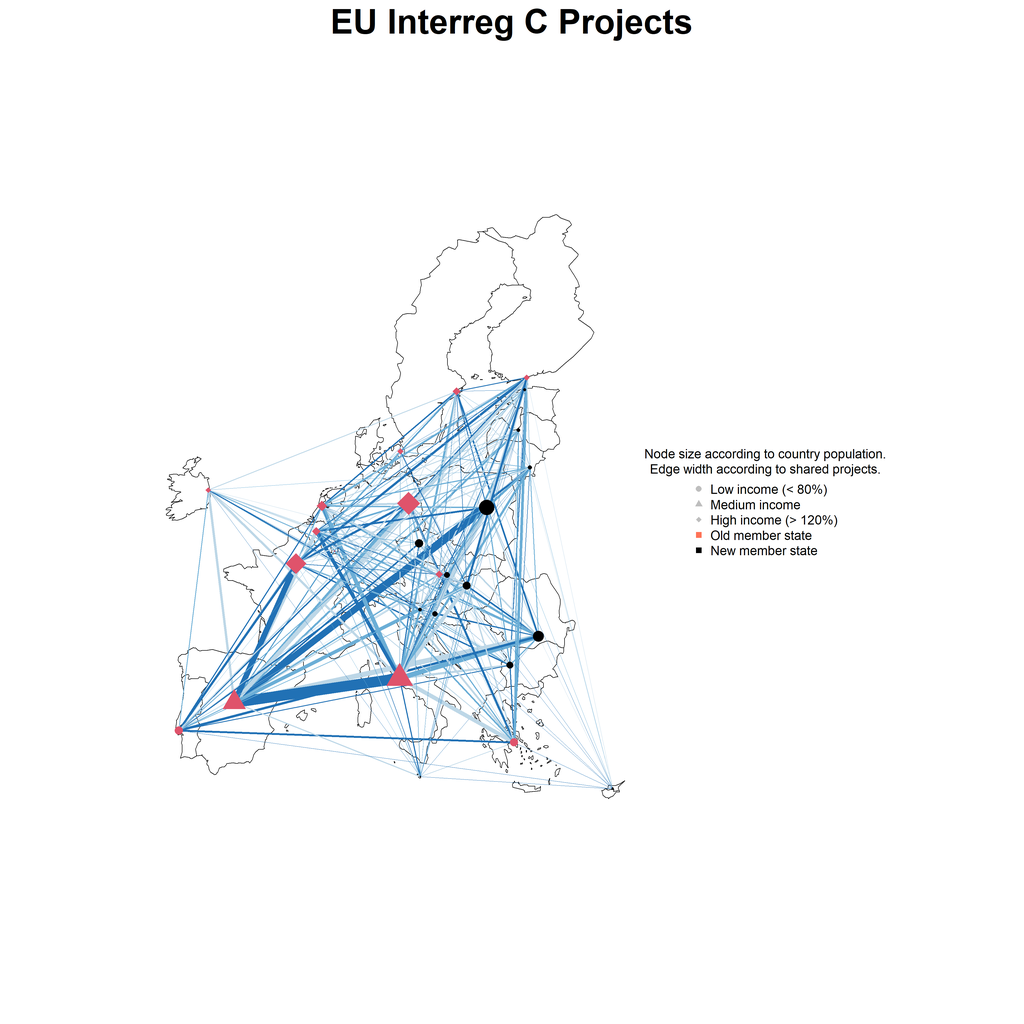

# Theory

Participation in interregional projects could depend on regional institutions: the higher their autonomy, the greater their ability to participate in transnational projects. Other explanatory factors are relational. Recent work shows that EU integration is a differentiated process. Winzen and Schimmelfennig describe an “inclusive core” composed of the earliest member states and a “reclusive periphery” of newer members in the East and North. On an abstract level, this literature defines two main logics of differentiation: some more developed members participating less, permanently, and less developed accession countries participating less at the beginning. A network-based approach can untangle these factors and account for structural effects which may act independently from country characteristics.

H1: *Countries with higher regional autonomy are more likely to be involved in interregional projects.*

H2: *Common projects are more likely for partners from countries with similar levels of economic development.*

H3: *Common projects are more likely for a) partners from the older core EU member states or b) from the newer member states.*

H4 *Common projects are more likely when they involve partners of partners.*

# Data

The main source of data for this piece is a list of project operations under the Interreg C scheme whose funding begun between 2016 and 2019, kindly provided by the EU Interreg Office in Lille. Additional country-level characteristics were drawn from other sources: Economic development was measured through per capita GDP (in 2014, the year before the first project call, manually recoded in three groups: countries with less than 80% of the EU’s average per capita GDP, countries with more than 120% and a middle group). Regional autonomy was measured through the Regional Authority Index, again recoded in three groups. 2004, the year when 10 additional states joined the EU, was chosen as the cut-off date for “old members”. Projects involving partners from non-EU countries such as Norway and Switzerland, but also the UK were excluded from the dataset. A country’s population size (square root) was included as a control variable.

# Model

The analysis was conducted using an exponential-family random graph model (ERGM), with the tie between a country and a project as the unit of analysis. This configuration was chosen over an actor-oriented model as the data only contains the projects that were funded, as opposed to all the project applications submitted, possibly distorting actors’ original preferences. H1 was tested through a nodal effect H2 and H3 were explored by testing dyad-level homophily effects, and H4 through an effect based on geometrically weighted dyadwise-shared partners (GWDSP).

| Term | Estimate | Standard Error | MCMC Error | Statistic | p value |
| --- | --- | --- | --- | --- | --- |
| edges | -1.6899643 | 0.2270870 | 0 | -7.4419245 | 0.0000000 |
| b2cov.Popsqrt | 0.0001369 | 0.0000234 | 0 | 5.8444500 | 0.0000000 |
| b2factor.oldmember.TRUE | 0.4340091 | 0.4851007 | 0 | 0.8946783 | 0.3709591 |
| b2nodematch.oldmember.FALSE | -0.3319445 | 0.1319795 | 0 | -2.5151225 | 0.0118991 |
| b2nodematch.oldmember.TRUE | -0.1937109 | 0.1037933 | 0 | -1.8663145 | 0.0619974 |
| b2factor.incomecat.2 | 0.5816045 | 0.4865053 | 0 | 1.1954740 | 0.2319019 |
| b2factor.incomecat.3 | -0.3017948 | 0.3647359 | 0 | -0.8274337 | 0.4079913 |
| b2nodematch.incomecat.1 | 0.0538963 | 0.1012023 | 0 | 0.5325601 | 0.5943381 |
| b2nodematch.incomecat.2 | -0.5816567 | 0.3610225 | 0 | -1.6111368 | 0.1071499 |
| b2nodematch.incomecat.3 | -0.0705915 | 0.1223349 | 0 | -0.5770346 | 0.5639161 |
| b2factor.regionautonomy.2 | 0.2628905 | 0.1148975 | 0 | 2.2880426 | 0.0221350 |
| b2factor.regionautonomy.3 | 0.3536718 | 0.1785504 | 0 | 1.9807953 | 0.0476142 |
| gwdsp.fixed.0.25 | 0.0728471 | 0.0131494 | 0 | 5.5399603 | 0.0000000 |

# Discussion

H1: When countries have a higher level of regional autonomy, project participation becomes more likely, as expected.

H3: Both older and newer member states display heterophily, in that the same value on this attribute reduces the probability of ties to a common project. The significance of this effect was higher for the new member states.

H4: Shared partners made it more likely for a country to participate in a project with another country. Goodness-of-fit results (cf. Annex) show that some degree levels were under- or overrepresented in the simulations. The model could certainly be improved through further fine-tuning.

The overall results show that while there are differentiated patterns of project participation, these are not driven by homophily in terms of economic development levels or accession date. Rather, where there are significant findings, these point towards heterophily, which is the most pronounced between older and newer member states. Furthermore, structural effects play a role: Dyadwise-shared partners increase the likelihood of a tie being formed. While there is certainly differentiation in Interreg participation, the programme generally fulfilled its goal of bridging gaps, between development levels and old and new members.

Future analyses should strive for a more fine-grained picture, with data closer to the regional level of decision and micro-level actor-oriented theories. Further analytical value could be gained with a complete dataset of Interreg projects since their beginning in 2000, as these regional networks are likely to autocorrelate over time.

# Annex : Goodness of fit

**Click to expand**

Goodness of fit

|  | obs | min | mean | max | MC p-value |
| --- | --- | --- | --- | --- | --- |
| b2deg0 | 0 | 0 | 0.00 | 0 | 1.00 |
| b2deg1 | 0 | 0 | 0.00 | 0 | 1.00 |
| b2deg2 | 1 | 0 | 0.00 | 0 | 0.00 |
| b2deg3 | 0 | 0 | 0.00 | 0 | 1.00 |
| b2deg4 | 0 | 0 | 0.01 | 1 | 1.00 |
| b2deg5 | 0 | 0 | 0.00 | 0 | 1.00 |
| b2deg6 | 0 | 0 | 0.00 | 0 | 1.00 |
| b2deg7 | 0 | 0 | 0.02 | 1 | 1.00 |
| b2deg8 | 0 | 0 | 0.04 | 1 | 1.00 |
| b2deg9 | 1 | 0 | 0.13 | 1 | 0.26 |
| b2deg10 | 0 | 0 | 0.11 | 2 | 1.00 |
| b2deg11 | 0 | 0 | 0.13 | 1 | 1.00 |
| b2deg12 | 0 | 0 | 0.27 | 2 | 1.00 |
| b2deg13 | 1 | 0 | 0.34 | 2 | 0.60 |
| b2deg14 | 1 | 0 | 0.42 | 3 | 0.70 |
| b2deg15 | 1 | 0 | 0.52 | 3 | 0.82 |
| b2deg16 | 3 | 0 | 0.45 | 2 | 0.00 |
| b2deg17 | 0 | 0 | 0.58 | 3 | 1.00 |
| b2deg18 | 0 | 0 | 0.71 | 3 | 0.94 |
| b2deg19 | 0 | 0 | 0.69 | 3 | 1.00 |
| b2deg20 | 1 | 0 | 0.82 | 4 | 1.00 |
| b2deg21 | 0 | 0 | 0.90 | 4 | 0.80 |
| b2deg22 | 0 | 0 | 0.83 | 4 | 0.74 |
| b2deg23 | 0 | 0 | 0.99 | 4 | 0.70 |
| b2deg24 | 0 | 0 | 0.82 | 5 | 0.74 |
| b2deg25 | 0 | 0 | 0.82 | 4 | 0.84 |
| b2deg26 | 0 | 0 | 0.81 | 4 | 0.90 |
| b2deg27 | 2 | 0 | 1.02 | 3 | 0.62 |
| b2deg28 | 1 | 0 | 0.85 | 3 | 1.00 |
| b2deg29 | 0 | 0 | 0.85 | 3 | 0.84 |

[output cut: 130 more lines]